# Assignment 7

PFL

2023-01-24

### 1

Using the built-in starwars data set in the dplyr package, create a new tibble with the following modifications:

-It only includes the species that have more than 1 individual represented in the data set. (hint: first use dplyr to summarize the number of individuals per species in the data frame; then create a vector/tibble of those names; subset the species that are included in that vector)

-It only includes the columns that are not of type list (hint: use glimpse to check)

```r
library(dplyr)
library(tidyverse)
common_sw_species <- starwars %>%
  group_by(species) %>%
  count() %>%
  arrange(desc(n))%>%
  filter(n>1)
common_sw_species
```

```
## # A tibble: 9 × 2
## # Groups:   species [9]
##   species      n
##   <chr>    <int>
## 1 Human       35
## 2 Droid        6
## 3 <NA>         4
## 4 Gungan       3
## 5 Kaminoan     2
## 6 Mirialan     2
## 7 Twi'lek      2
## 8 Wookiee      2
## 9 Zabrak       2
```

```r
 filteredsw<- starwars %>%
  filter(species %in% common_sw_species$species) %>%
  arrange(by=species) %>%
  select(1:11)
 view(filteredsw)
```

### 2

Clean your data set: only include observations/rows that do not have an NA in the height column. Then, use dplyr to print a summary table showing the mean, median, and standard deviation of height for each species.

```r
library(tidyr)

filteredheight <- filteredsw[!is.na(filteredsw$height),]
anyNA(filteredheight$height)
```

```
## [1] FALSE
```

```r
filteredheight
```

```
## # A tibble: 52 × 11
##    name        height  mass hair_…¹ skin_…² eye_c…³ birth…⁴ sex   gender homew…⁵
##    <chr>        <int> <dbl> <chr>   <chr>   <chr>     <dbl> <chr> <chr>  <chr>
##  1 C-3PO          167    75 <NA>    gold    yellow    112   none  mascu… Tatooi…
##  2 R2-D2           96    32 <NA>    white,… red        33   none  mascu… Naboo
##  3 R5-D4           97    32 <NA>    white,… red        NA   none  mascu… Tatooi…
##  4 IG-88          200   140 none    metal   red        15   none  mascu… <NA>
##  5 R4-P17          96    NA none    silver… red, b…    NA   none  femin… <NA>
##  6 Jar Jar Bi…    196    66 none    orange  orange     52   male  mascu… Naboo
##  7 Roos Tarpa…    224    82 none    grey    orange     NA   male  mascu… Naboo
##  8 Rugor Nass     206    NA none    green   orange     NA   male  mascu… Naboo
##  9 Luke Skywa…    172    77 blond   fair    blue       19   male  mascu… Tatooi…
## 10 Darth Vader    202   136 none    white   yellow     41.9 male  mascu… Tatooi…
## # … with 42 more rows, 1 more variable: species <chr>, and abbreviated variable
## #   names ¹hair_color, ²skin_color, ³eye_color, ⁴birth_year, ⁵homeworld
```

```r
filteredheight2 <- filteredsw[complete.cases(filteredsw$height),]
anyNA(filteredheight2$height)
```

```
## [1] FALSE
```

```r
heightsummary <- filteredheight %>%
  group_by(species) %>%
  summarize(MeanHeight=mean(height), MedianHeight=median(height), StandardDeviation=sd(height))
print(heightsummary)
```

```
## # A tibble: 9 × 4
##   species  MeanHeight MedianHeight StandardDeviation
##   <chr>         <dbl>        <dbl>             <dbl>
## 1 Droid          131.           97             49.1
## 2 Gungan         209.          206             14.2
## 3 Human          177.          180             12.5
## 4 Kaminoan       221           221             11.3
## 5 Mirialan       168           168              2.83
## 6 Twi'lek        179           179              1.41
## 7 Wookiee        231           231              4.24
## 8 Zabrak         173           173              2.83
## 9 <NA>           181.          183              2.89
```

### 3

Create a box plot figure that shows the variation in heights among Star Wars species. Do the values in your summary table line up with the plot? Code so that each box plot (Species) is be filled with a different color. Change your axes labels so that species is capitalized and height is capitalized and shows units (cm). Use a different theme option. Then look into the annotate or geom_text functions and add the text “p=1.2E-0.5” to the top right corner.

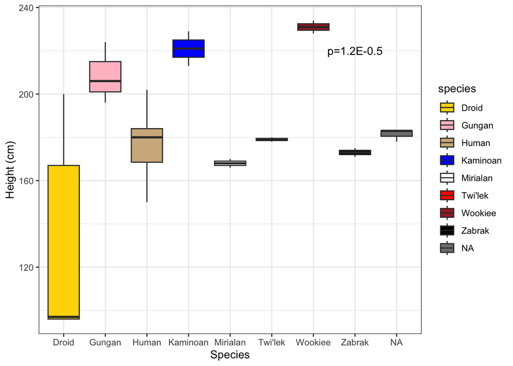

```r
library(ggplot2)
library(viridisLite)

p  <- ggplot(data = filteredheight, aes(y=height, x=species, fill=species)) + geom_boxplot() + xlab("Species") + ylab("Height (cm)") + scale_fill_manual(values=c("gold", "pink", "tan", "blue", "white", "red", "brown", "black", "green")) + theme_bw() + annotate("text", x=8, y=220, label="p=1.2E-0.5")


p
```

## Challenge

### 4

Using the same or a different built-in data set, create at least one additional (and different kind of) plot. Experiment with different arguments, features, and colors.

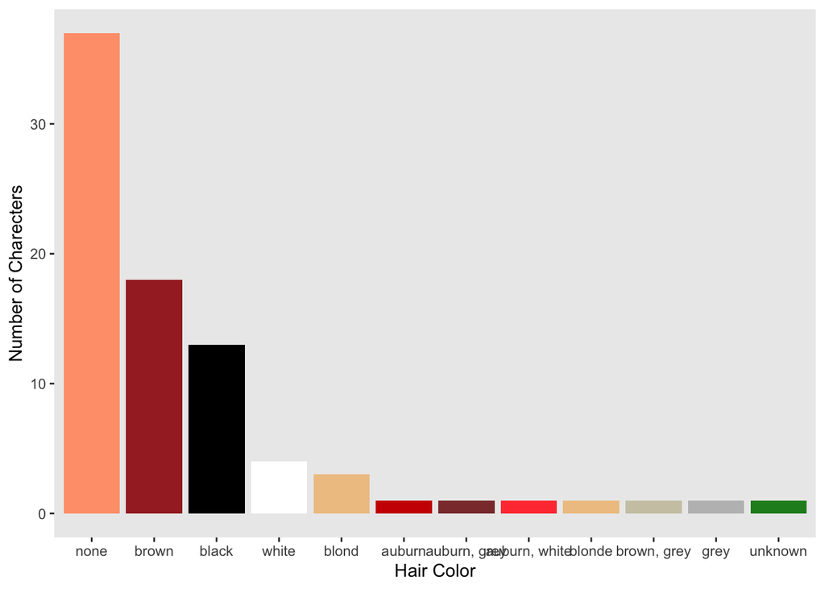

```r
library(tidyverse)
library(ggthemes)
library(dplyr)
library(plotrix)
library(ggplot2)
view(starwars)
starwars$hair_color <- factor(starwars$hair_color, levels=c("none","brown","black","white","blond","auburn","auburn, grey","auburn, white","blonde","brown, grey","grey","unknown"))


haircolor <- starwars %>%
  select(c(name, hair_color)) %>%
  na.omit(hair_color) %>%
  arrange(hair_color) %>%
  group_by(hair_color) %>%
  count() %>%
  arrange(desc(n))%>%
  as_tibble

view(haircolor)

hairplot <- ggplot(data=haircolor,
                   aes(x= reorder(hair_color, -n), y=n, fill=hair_color)) +
  geom_bar(stat = "identity") +
  ylab("Number of Charecters") +
  xlab("Hair Color") +
  scale_fill_manual(values=c("lightsalmon","brown","black","white","burlywood2","red3","indianred4","brown1", "burlywood2",  "cornsilk3", "grey", "forestgreen" ))


hairplot + theme(panel.grid.major = element_blank(),
             panel.grid.minor = element_blank(),
             legend.position = "none")
```

### 5

Finally, create a multi-panel figure with the graphs you created.

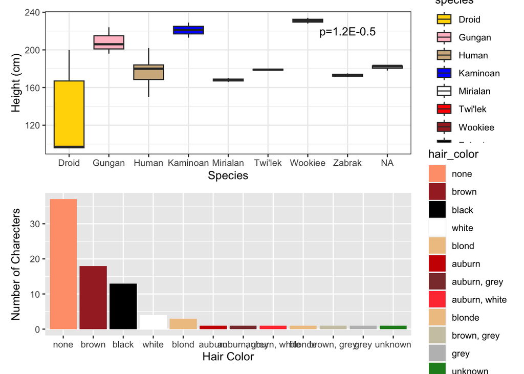

```r
library(patchwork)
p / hairplot
```